# HW 3

setwd(“~/Desktop/Predictive Analytics/Assignment/HW 3”)

# 3.13

## a)

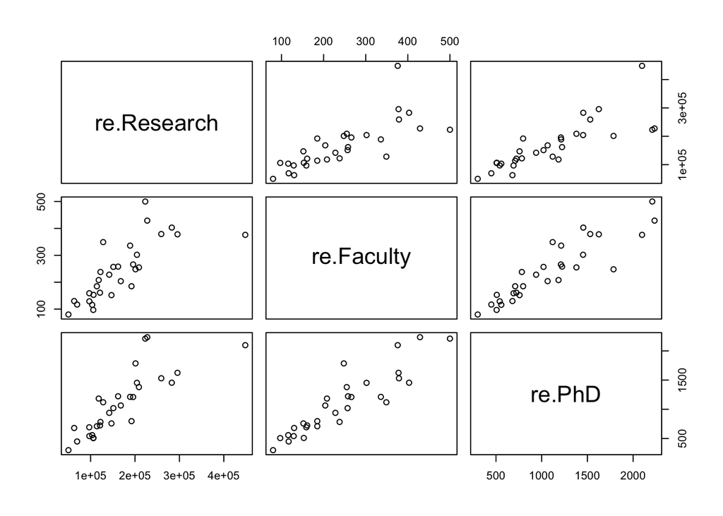

```r
library(stringr)
re <- read.csv("Research.csv")
fee1 = str_replace(re$Research,"\\$","")
fee2 = str_replace(fee1,",","")
fee = as.numeric(fee2)
re$Research = fee
mat_re <- data.frame(re$Research,re$Faculty,re$PhD)
plot(mat_re)
```

```r
va <- data.frame(re$Research,re$Faculty,re$PhD)
cor(va)
```

```
##             re.Research re.Faculty    re.PhD
## re.Research   1.0000000  0.7648421 0.8174254
## re.Faculty    0.7648421  1.0000000 0.9036829
## re.PhD        0.8174254  0.9036829 1.0000000
```

Research expenditures are positively related to number of faculty and number of PhD students.

## b)

```r
fit_re = lm(Research ~ Faculty + PhD, data = re)
summary(fit_re)
```

```
##
## Call:
## lm(formula = Research ~ Faculty + PhD, data = re)
##
## Residuals:
##    Min     1Q Median     3Q    Max
## -90804 -16921  -2921  13605 159743
##
## Coefficients:
##             Estimate Std. Error t value Pr(>|t|)
## (Intercept) 23525.91   22034.47   1.068   0.2951
## Faculty       107.13     193.39   0.554   0.5842
## PhD           107.14      40.06   2.675   0.0125 *
## ---
## Signif. codes:  0 '***' 0.001 '**' 0.01 '*' 0.05 '.' 0.1 ' ' 1
##
## Residual standard error: 49040 on 27 degrees of freedom
## Multiple R-squared:  0.6719, Adjusted R-squared:  0.6476
## F-statistic: 27.65 on 2 and 27 DF,  p-value: 2.923e-07
```

## c)

```r
library(ppcor)
pcor.test(re$Research,re$Faculty,re$PhD)
```

| estimate | p.value | statistic | n | gp | Method |
| --- | --- | --- | --- | --- | --- |
| 0.1060117 | 0.5841555 | 0.5539747 | 30 | 1 | pearson |

```r
pcor.test(re$Research,re$PhD,re$Faculty)
```

| estimate | p.value | statistic | n | gp | Method |
| --- | --- | --- | --- | --- | --- |
| 0.4576694 | 0.01254632 | 2.674682 | 30 | 1 | pearson |

t-statistics are the same as b.

# 3.14

## a)

```r
x1 <- matrix(c(31,46,40,49,38,49,31,38,33,42))
xp <- (x1 - mean(x1)) / sd(x1)
x2 <- matrix(c(1.85,2.8,2.2,2.85,1.8,2.8,1.85,2.3,1.6,2.15))
xq <- (x2 - mean(x2)) / sd(x2)
x <- cbind(xp,xq)
```

The R is:

```r
R <- t(x) %*% x / (10 - 1)
R
```

```
##           [,1]      [,2]
## [1,] 1.0000000 0.9132577
## [2,] 0.9132577 1.0000000
```

The r is:

```r
y1 <- matrix(c(4.2,7.28,5.6,8.12,5.46,7.42,3.36,5.88,4.62,5.88))
y <- (y1 - mean(y1)) / sd(y1)
r <- t(x) %*% y / (10 - 1)
r
```

```
##           [,1]
## [1,] 0.9708553
## [2,] 0.9040219
```

$\color{red}{{r_{yx1 \mid x2}}\ {r_{yx2 \mid x1}}\ are:}$

```r
(r[1,1] - r[2,1] * R[1,2]) / sqrt((1 - r[2,1]^2) * (1 - R[1,2]^2))
```

```
## [1] 0.8340515
```

```r
(r[2,1] - r[1,1] * R[1,2]) / sqrt((1 - r[1,1]^2) * (1 - R[1,2]^2))
```

```
## [1] 0.1780173
```

## b)

$\color{red}{\hat{\beta_1}^*\ and\ {\hat{\beta_2}^*\ are:}}$

```r
b = solve(R) %*% r
b
```

```
##           [,1]
## [1,] 0.8752107
## [2,] 0.1047290
```

$\color{red}{\hat{\beta_1}^*\ and\ \hat{\beta_2}^*\ are\ slightly\ different\ from\ {r_{yx1 \mid x2}}\ and\ {r_{yx2 \mid x1}}}$

## c)

```r
fit = lm(y1 ~ x1 + x2)
summary(fit)
```

```
##
## Call:
## lm(formula = y1 ~ x1 + x2)
##
## Residuals:
##     Min      1Q  Median      3Q     Max
## -0.6235 -0.2984  0.1186  0.3058  0.3976
##
## Coefficients:
##             Estimate Std. Error t value Pr(>|t|)
## (Intercept) -2.60615    0.80421  -3.241  0.01424 *
## x1           0.19224    0.04806   4.000  0.00519 **
## x2           0.34063    0.71166   0.479  0.64679
## ---
## Signif. codes:  0 '***' 0.001 '**' 0.01 '*' 0.05 '.' 0.1 ' ' 1
##
## Residual standard error: 0.4013 on 7 degrees of freedom
## Multiple R-squared:  0.9444, Adjusted R-squared:  0.9285
## F-statistic: 59.43 on 2 and 7 DF,  p-value: 4.058e-05
```

$\color{red}{\hat{\beta_1}\ and\ \hat{\beta_2}\ are\ not\ equal\ to\ \hat{\beta_1}^*\ and\ \hat{\beta_2}^*\\}$

$\color{red}{after\ scaling:}$

```r
b1 = b[1,1] * (sd(y1) / sd(x1))
b2 = b[2,1] * (sd(y1) / sd(x2))
b1
```

```
## [1] 0.1922408
```

```r
b2
```

```
## [1] 0.3406266
```

## d)

$\color{red}{\hat{\beta_1}^*\ \hat{\beta_2}^*}$are better. After standardization, variables are unitless without weight, and can be used for prediction.

# 4.4

## a)

```r
gpa = read.csv("GPA.csv")
qmfit = lm(GPA ~ Verbal + Math +  I(Verbal^2) + I(Math^2) + Verbal * Math, data = gpa)
summary(qmfit)
```

```
##
## Call:
## lm(formula = GPA ~ Verbal + Math + I(Verbal^2) + I(Math^2) +
##     Verbal * Math, data = gpa)
##
## Residuals:
##      Min       1Q   Median       3Q      Max
## -0.39203 -0.10935 -0.04432  0.09508  0.42601
##
## Coefficients:
##               Estimate Std. Error t value Pr(>|t|)
## (Intercept) -9.9167631  1.3544134  -7.322 1.75e-08 ***
## Verbal       0.1668098  0.0212447   7.852 3.85e-09 ***
## Math         0.1375972  0.0267340   5.147 1.11e-05 ***
## I(Verbal^2) -0.0011082  0.0001173  -9.449 4.88e-11 ***
## I(Math^2)   -0.0008433  0.0001594  -5.290 7.23e-06 ***
## Verbal:Math  0.0002411  0.0001440   1.675    0.103
## ---
## Signif. codes:  0 '***' 0.001 '**' 0.01 '*' 0.05 '.' 0.1 ' ' 1
##
## Residual standard error: 0.1871 on 34 degrees of freedom
## Multiple R-squared:  0.9366, Adjusted R-squared:  0.9272
## F-statistic: 100.4 on 5 and 34 DF,  p-value: < 2.2e-16
```

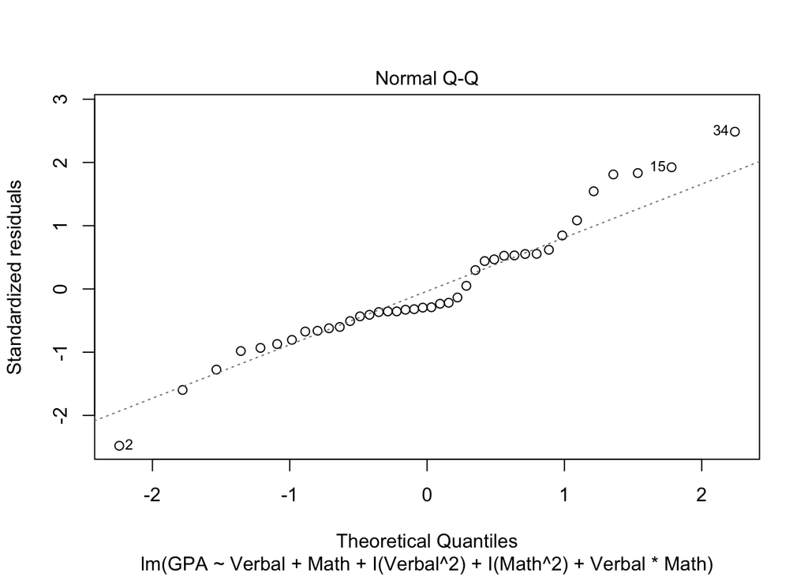

```r
plot(qmfit,which = 2)
```

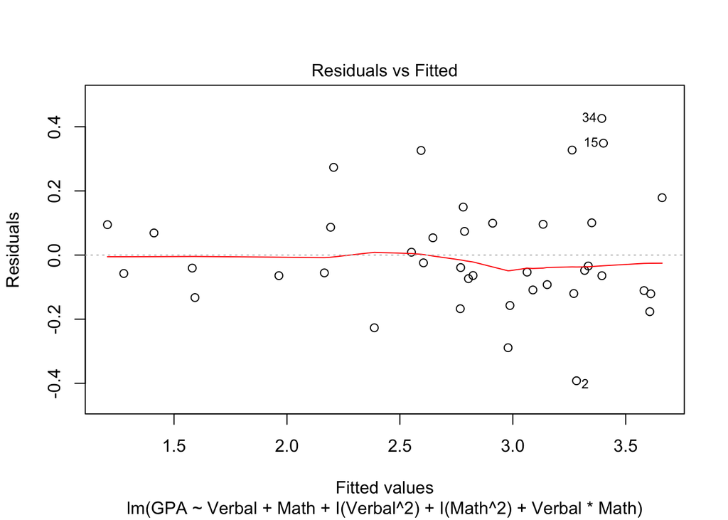

```r
plot(qmfit,which = 1)
```

Observations do not fit the linear model due to outliers, and the normality is violated. Residuals are not evenly distributed between parral lines, and the homoscedasticity is violated. The residuals fan out approximatedly in a funnel shape indicating a log transformation.

## b)

```r
qmfit1 = lm(log(GPA) ~ Verbal + Math +  I(Verbal^2) + I(Math^2) + Verbal * Math, data = gpa)
summary(qmfit1)
```

```
##
## Call:
## lm(formula = log(GPA) ~ Verbal + Math + I(Verbal^2) + I(Math^2) +
##     Verbal * Math, data = gpa)
##
## Residuals:
##       Min        1Q    Median        3Q       Max
## -0.138636 -0.056735  0.008366  0.046788  0.159979
##
## Coefficients:
##               Estimate Std. Error t value Pr(>|t|)
## (Intercept) -5.479e+00  5.311e-01 -10.315 5.24e-12 ***
## Verbal       8.591e-02  8.331e-03  10.311 5.29e-12 ***
## Math         7.433e-02  1.048e-02   7.090 3.44e-08 ***
## I(Verbal^2) -5.248e-04  4.600e-05 -11.410 3.58e-13 ***
## I(Math^2)   -4.199e-04  6.252e-05  -6.717 1.02e-07 ***
## Verbal:Math -5.345e-07  5.646e-05  -0.009    0.993
## ---
## Signif. codes:  0 '***' 0.001 '**' 0.01 '*' 0.05 '.' 0.1 ' ' 1
##
## Residual standard error: 0.07339 on 34 degrees of freedom
## Multiple R-squared:  0.9465, Adjusted R-squared:  0.9386
## F-statistic: 120.2 on 5 and 34 DF,  p-value: < 2.2e-16
```

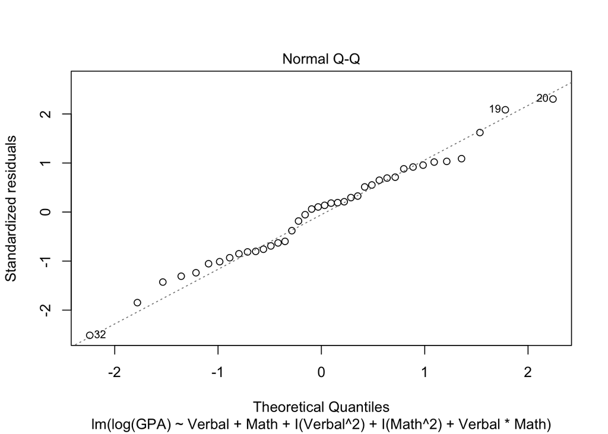

```r
plot(qmfit1,which = 2)
```

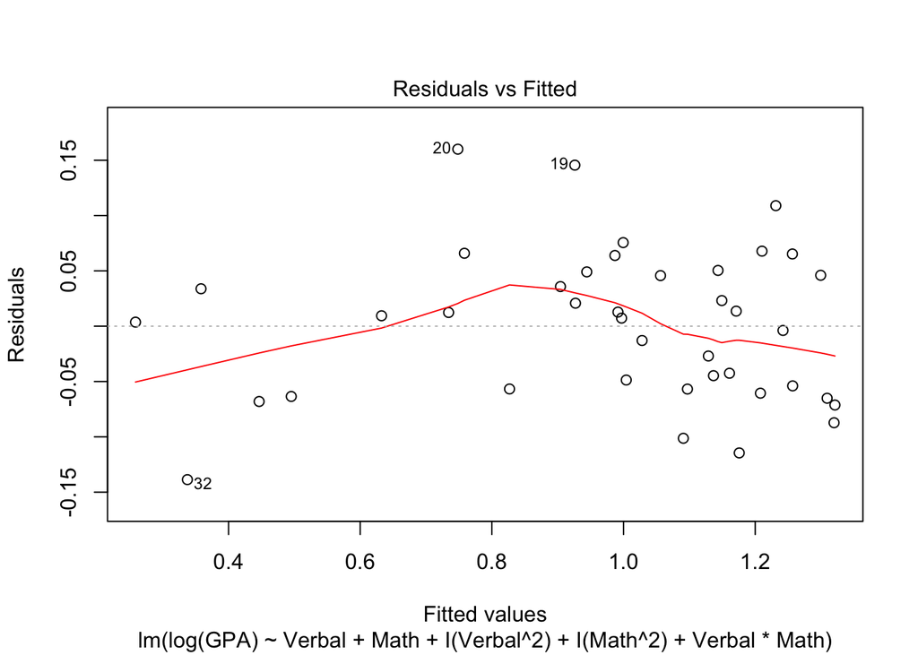

```r
plot(qmfit1,which = 1)
```

Most observations fit the linear model, the normality assumption is satisfied. More fitted values are evenly distributed, the homoscedasticity assumption is satisfied.

# 4.5

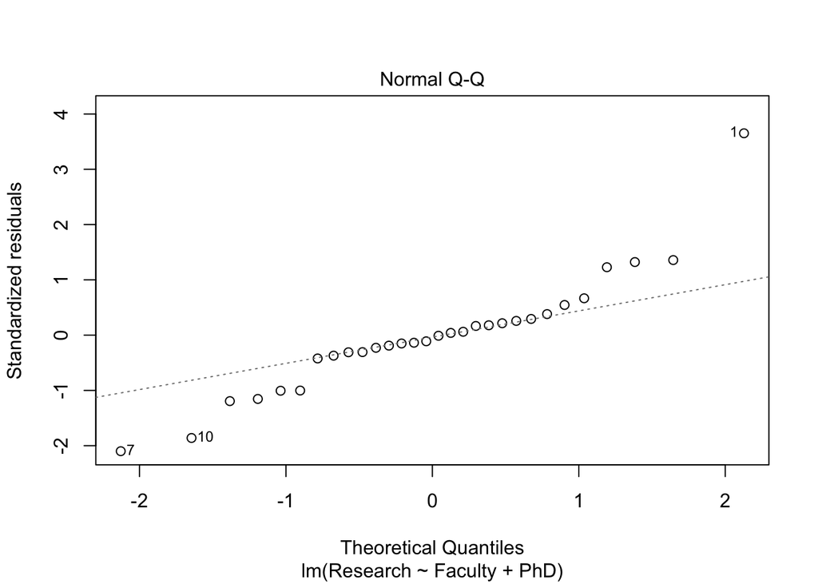

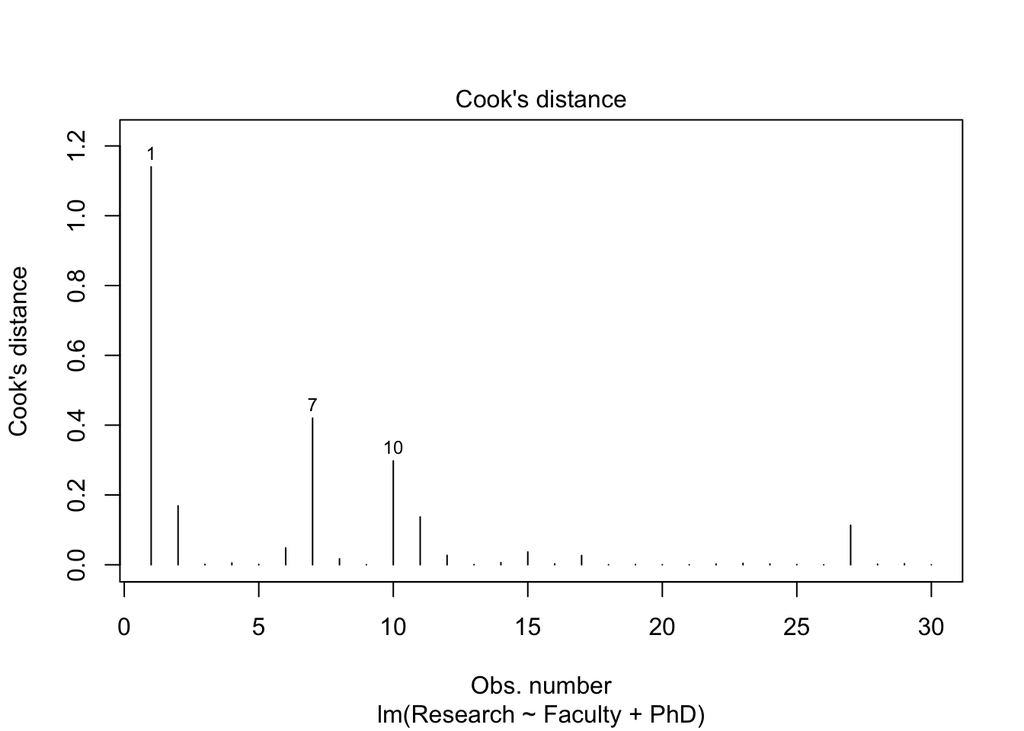

```r
plot(fit_re,which = c(4,2))
```

From theplot, it can be seen that university No. 1, 7, 10 are outliers.

Outliers and influencial observations are:

```r
re$University[c(1,7,10)]
```

```
## [1] MIT    GaTech UIUC
## 30 Levels: Berkeley CalTech CMU Columbia Cornell Duke GaTech ... Wisconsin
```

# 4.6

```r
salary <- read.csv("salaries.csv")
salary$Gender <- relevel(salary$Gender,ref = "Male")
salary$Dept <- relevel(salary$Dept,ref = "Purchase")
fit_salary = lm(log10(salary$Salary) ~ salary$YrsEm+salary$Education+salary$Dept)
fit_salary1 = lm(salary$Salary ~ salary$YrsEm+salary$Education+salary$Dept)
```

## a)

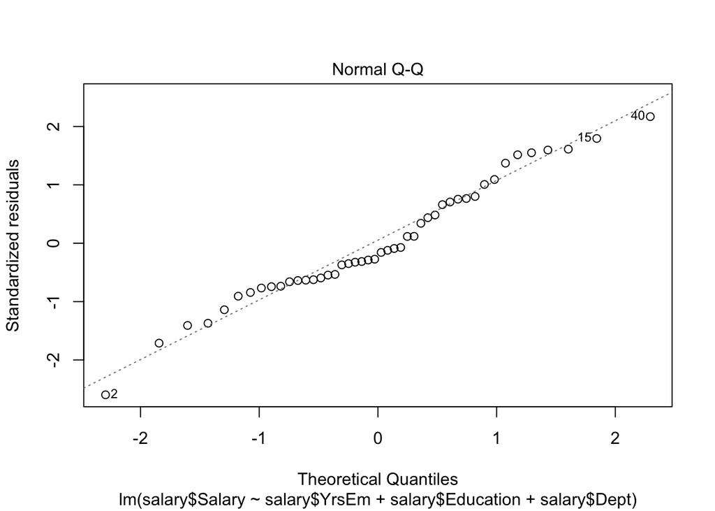

```r
plot(fit_salary1,which = 2)
```

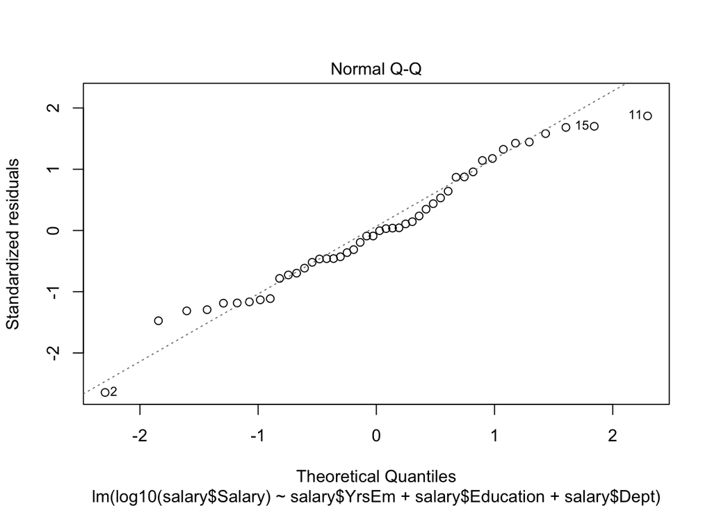

```r
plot(fit_salary,which = 2)
```

The log transformation of salary improves normality.

## b)

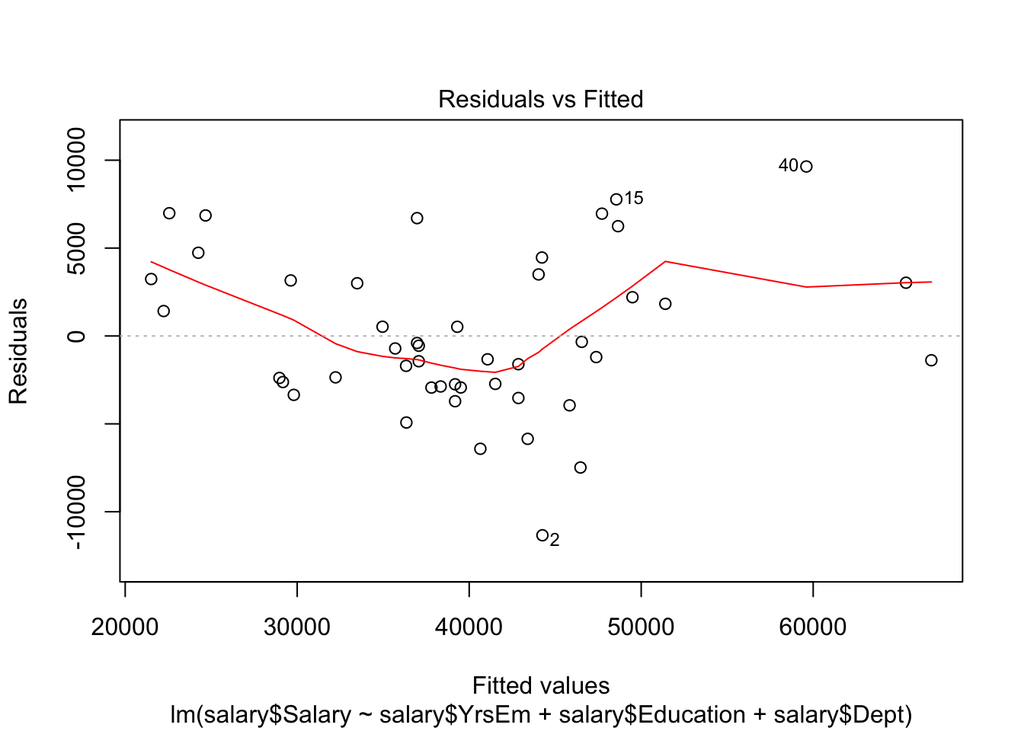

```r
plot(fit_salary1,which = 1)
```

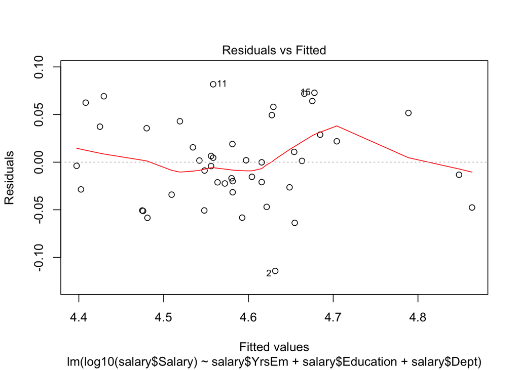

```r
plot(fit_salary,which = 1)
```

The log transformation of salary improves homoscedasticity